# Session 4: Rmarkdown

Mobina Pourmoshir

2/9/2024

# RMarkdown

[figure not shown]

image

- [R Markdown](http://rmarkdown.rstudio.com/) at its core is a combination of [`R`](https://cran.r-project.org/) and [Markdown](https://daringfireball.net/projects/markdown/) used to generate reproducible reports for data analyses.
- R Markdown provides an authoring framework for data science.
- You can use a single R Markdown file to
  - save and execute code
  - generate high quality reports that can be shared with an audience

# Rmarkdown

- Markdown and `R` are mixed together in a `.Rmd` file, which can then be rendered into a number of formats including `.html`, `.pdf`, and `.docx`.
- Fully reproducible reports
  - Have code, results, and text in the same document
  - Results are generated from the source code, and your documents are automatically updated if your data changed.

[figure not shown]

# Markdown

- R Markdown is based on markdown, a markup language that that you can use to add formatting elements to plaintext text documents.
- Markdown is a lightweight and easy-to-use syntax that is widely used to generate HTML pages and for styling the writing on the GitHub platform.
- It was created by John Gruber in 2004 and it is now one of the world’s most popular markup languages.
- We go through basic markdown syntax together, and you can learn more at:
  - [Markdown Tutorial](https://www.markdowntutorial.com/)
  - [Mastering Markdown GitHub Guides](https://docs.github.com/en/get-started/writing-on-github/getting-started-with-writing-and-formatting-on-github/basic-writing-and-formatting-syntax)
  - [Markdown Guide](https://www.markdownguide.org/getting-started/)

# R Markdown file

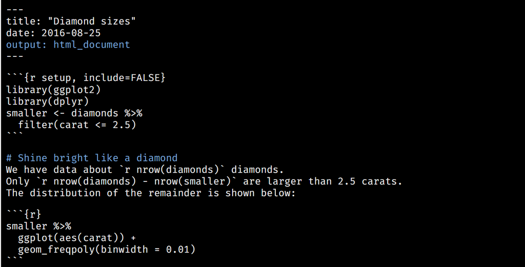

# YAML Header

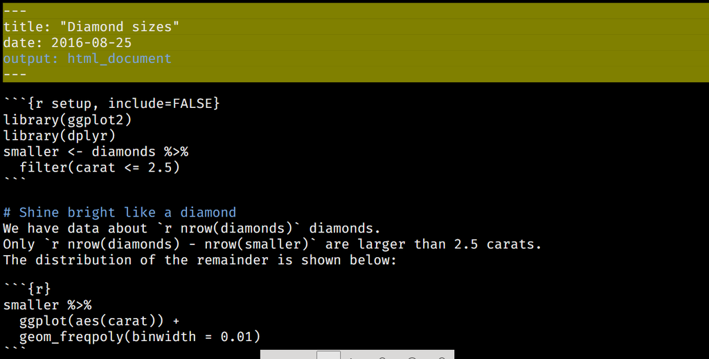

# Text

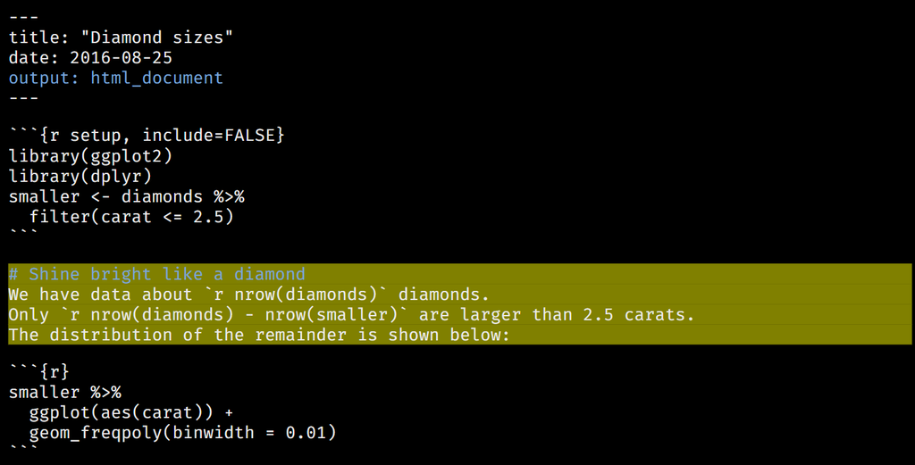

# Code Chunk

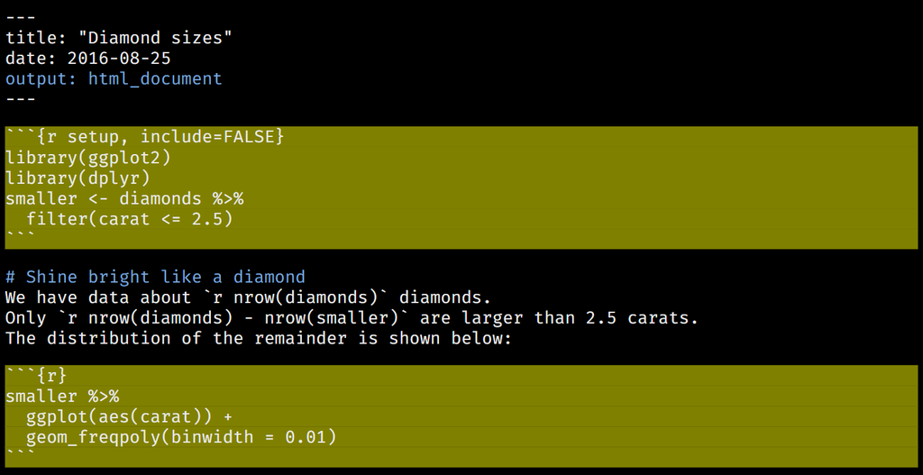

# Text Formatting and Headings

Formatting text is easy.

| Syntax | Output |
| --- | --- |
| **This is bold.** | **This is bold.** |
| *This is italics.* | *This is italics.* |
| `This text appears as monospaced.` | `This text appears as monospaced.` |
| subscript~2~ | subscript<sub>2</sub> |
| superscript<sup>2</sup> | superscript<sup>2</sup> |
| ~~strikethrough~~ | strikethrough |
| escaped: \* \_ \\ | escaped: * _ \ |
| endash: -- | endash: – |
| emdash: --- | emdash: — |

# Headers and Quotes

#### Headers

Headers are created by preceeding the line with a (#) sign. There are six levels. Each level has one more (#) sign than the preceeding level.

```
# The largest heading
## The second largest heading
###### The smallest heading
```

#### Quoting text

Texts are coding by preceeding the line with a (>) sign.

> I love MATH 4730!

#### Quoting code

A code or command within a sentence can be called with by wrapping the code in a single backtick (`).

Use `git status` to list all new or modified files that haven’t yet been committed.  
Triple backticks (```) are used as wrappers when a block of code is required.

```
The following code will be contained in a block.
git add
git commit
git status
```

# Link

##### Inline Links

To create an inline link, wrap the link text in brackets ([ ]), followed immediately by the link (href) in parentheses (()).  
[Google link](https://www.google.com)

##### Auto Linking

Any valid URL found within the text will automatically be converted to a clickable link.  
Putting the url of google https://www.google.com here.

##### Anchor Links

You can create an anchor link for a header or list item by ending the link with curly braces ({}) enclosing a hash mark (#) followed by the link id.

##### Header with ID

- List item 1 with ID {#listid1}
- List item 2 with ID {#listid2}

Create a link to : Inline Links

# List

##### Unordered Lists

To create an unordered list, put each list item on a separate line, and precede each list item with either an asterisk (*) or a dash (-).

- You do not need any header before the beginning of the list items.
- You do not need a blank line before the first list item (though it may help readability).
- item 1.
- item 2.
  - sub item 1
  - sub item 2

##### Ordered Lists

To create an ordered list, put each list item on a separate line, and precede each list item with a number.

1. You do not need any header before the beginning of the list items.
2. You do not need a blank line before the first list item (though it may help readability).
3. The numbers you place at the beginning of each list item do not matter; the list will automatically be re-numbered starting with the first list item.
4. item 1.
5. item 2.

##### Nested Lists

You can create a nested list by indenting one or more list items below another item.

1. First list item
   - First nested list item
     - Second nested list item

We could mix lists and links:

- [RMarkdown Documentation](http://rmarkdown.rstudio.com/)
- [RMarkdown Cheatsheet](https://www.rstudio.com/wp-content/uploads/2015/02/rmarkdown-cheatsheet.pdf)

# Maths & Tables

#### Maths

- **inline-maths** : To format an inline math code, wrap the math code with the ($) symbol.
  - $A= \pi r^2$.
- **math-block** : To format a block of math code, wrap the code with double ($$) symbol.
  - $$A= \pi r^2.$$

#### Tables

- [Table Generator](http://www.tablesgenerator.com/markdown_tables) Tables are sometimes tricky using Markdown.
- See the above link for a helpful Markdown table generator.

```
|Left column| Right column| Center column|
|:-----------|-----------:|:------------:|
|12          |          24| 11           |
|34          |          57| 76           |
```

| Left column | Right column | Center column |
| --- | --- | --- |
| 12 | 24 | 11 |
| 34 | 57 | 76 |

# Code Chucks

- To Insert a Code Chunk:
  - The “Insert” button icon
  - Keyboard shortcut **Cmd/Ctrl + Alt + I**

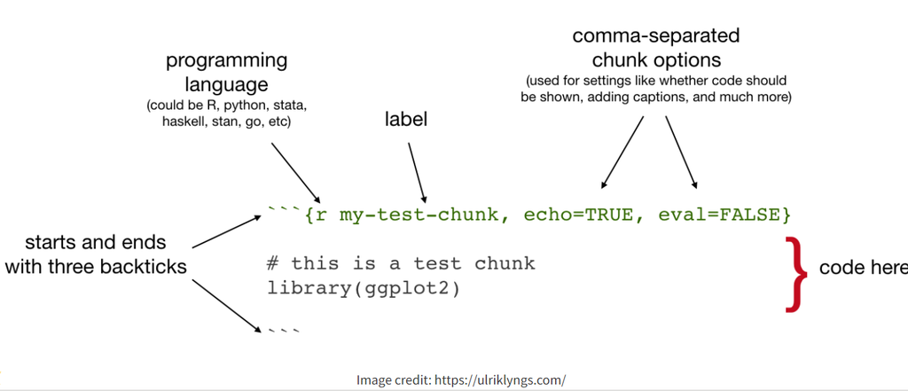

# Adding `R`

- The real power of RMarkdown comes when we add `R`.
- There are two ways we can do this. We can use `R` code chunks, or run `R` inline.

### `R` Chunks

The following is an example of an `R` code chunk

```r
# define function
get_sd <- function(x, biased = TRUE) {
  n = length(x) - 1 * !biased
  sqrt((1 / n) * sum((x - mean(x)) ^ 2))
}


# run function on randomly generated data
set.seed(42)
get_sd(rnorm(n = 10, mean = 2, sd = 5))
```

[output not shown]

#### Inline `R`

`R` can also be ran in the middle of exposition. For example, the sum of 3 and 7 is 10.

# Chunk Options

- The following table summarises which types of output each option suppresses:

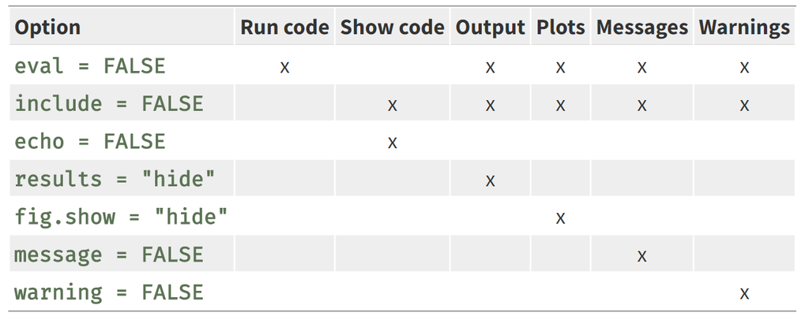

- Check [Knitr](https://yihui.org/knitr/options/) for more chunk options.

# Images & Plots

[figure not shown]

R Markdown logo

```r
knitr::include_graphics("C:/Users/PC/Desktop/Spring 2024/MATH 4730 Introduction to R/images/Week4/rmkdnsym.png")
```

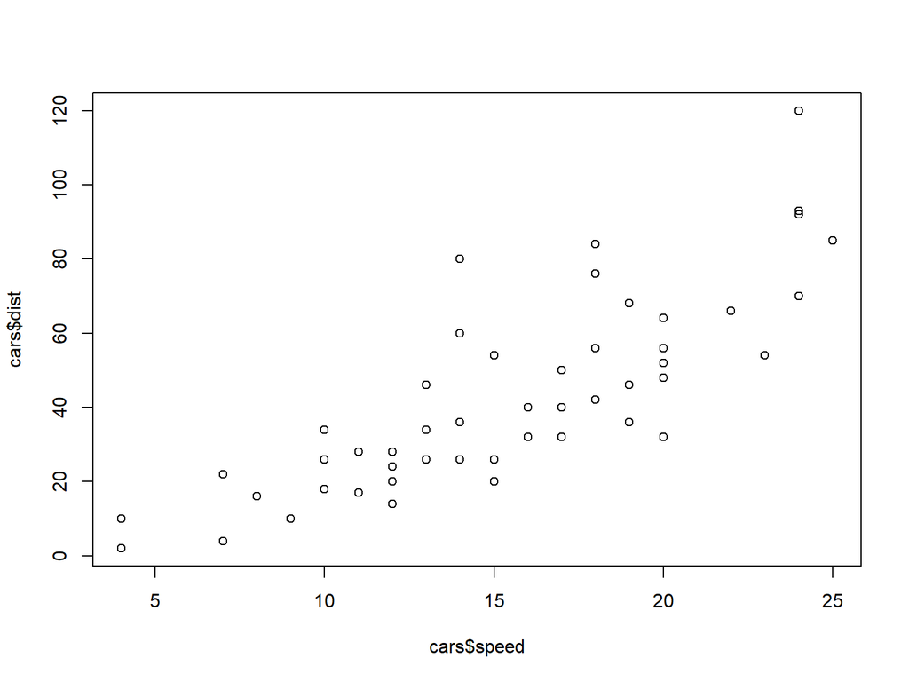

A plot of car stuff

```r
plot(x = cars$speed, y = cars$dist)
```

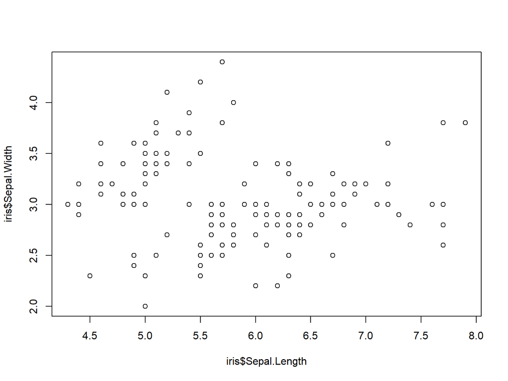

```r
plot(x=iris$Sepal.Length, y=iris$Sepal.Width)
```

# Adding Math with LaTeX

- RMarkdown is the ability to add [Latex for mathematics typesetting](https://www.latex-project.org/about/).
- There are two ways we can include Latex; displaystyle and inline.
- Note that use of LaTeX is somewhat dependent on the resulting file format. For example, it cannot be used at all with `.docx`. - To use it with `.pdf` you must have LaTeX install on your machine.
- With `.html` the LaTeX is not actually rendered during knitting, but actually rendered in your browser using MathJax.

#### Displaystyle LaTeX

Displaystyle is used for larger equations which appear centered on their own line.

```
\[
s = \sqrt{\frac{1}{n - 1}\sum_{i=1}^{n}(x - \bar{x})^2}
\]
```

$$s = \sqrt{\frac{1}{n - 1}\sum_{i=1}^{n}(x - \bar{x})^2}$$

#### Inline LaTex

We could mix LaTeX commands in the middle of exposition, for example: `$t = 2$` $t = 2$. We could actually mix `R` with Latex as well! For example: `$\bar{x} =3.5$` $\bar{x} = 3.5$.

# Output Options

- At the beginning of the document, there is code which describes some metadata and settings of the document.
- For this file, that code is:

```r
---
title: "RMarkdown Template"
author: "Your Name and Section"
date: ""
output:
  html_document:
    theme: readable
    toc: yes
---
```

- This describes the output format as html, defines the theme.
- `toc` tells `R` to automatically create a Table of Contents based on the headers and sub-headers you have defined using `#`.
- You can edit this yourself, or click the settings button at the top of the document and select `Output Options...`.
- You can explore other themes and syntax highlighting options, as well as many additional options.

# R Markdown Help

- RStudio’s tutorial: https://rmarkdown.rstudio.com
- [Help > Cheatsheet > R Markdown Cheat Sheet](https://www.rstudio.com/resources/cheatsheets/)
- [Ulrik Lyngs R Markdown Workshop](https://ulyngs.github.io/rmarkdown-workshop/)
- [R Markdown for Scientists](https://rmd4sci.njtierney.com/)
- [R Markdown: The Definitive Guide](https://bookdown.org/yihui/rmarkdown/)
- [R Markdown Cookbook](https://bookdown.org/yihui/rmarkdown-cookbook/)
- [Advanced R Markdown Workshop](https://arm.rbind.io/)

# Worksheet 2

1. Create an rmarkdown file that outputs a word document.
   - The title of the document should be “Worksheet 2”.
   - Put your name as the author.
2. Create an unordered list of groceries (5 items) with a level 3 header “Grocery”.
3. Create an ordered list out the list (Freshman, Sophomore, Junior, Senior, Graduate) with a level 3 header “Year”.
4. Insert the image uploaded on D2L in your document.
5. Create a link in your document connecting the text `"R Markdown"` to the url `"https://rmarkdown.rstudio.com/"`.
6. Insert an `R Chunk` with the options of showing both code and the output. The chunk should contain;
   - your working directory.
   - the structure of iris dataset.
   - first 5 observations of iris dataset.
   - plot the sepal length and sepal width of the iris dataset on the x-axis and y-axis respectively.
7. Knit your document and submit it to the Worksheet 2 folder in D2L.